# Some examples of use-cases using the market models of the package

This short tutorial covers the very basic use cases to get you started with *markets*. More usage details can be found in the documentation of the package.

## Setup the environment

Load the required libraries.

```r
library(markets)
library(Formula)
```

Prepare the data. Normally this step is long and depends on the nature of the data and the considered market. For this example, we will use simulated data. Although we could simulate data independently from the package, we will use the top-level simulation functionality of *markets* to simplify the process. See the documentation of `simulate_data` for more information on the simulation functionality. Here, we simulate data using a data generating process for a market in disequilibrium with stochastic price dynamics.

```r
nobs <- 1000
tobs <- 5

alpha_d <- -1.3
beta_d0 <- 24.8
beta_d <- c(2.3, -1.02)
eta_d <- c(2.6, -1.1)

alpha_s <- 0.6
beta_s0 <- 16.1
beta_s <- c(2.9)
eta_s <- c(-1.5, 3.2)

gamma <- 1.2
beta_p0 <- 0.9
beta_p <- c(-0.1)

sigma_d <- 1
sigma_s <- 1
sigma_p <- 1
rho_ds <- 0.0
rho_dp <- 0.0
rho_sp <- 0.0

seed <- 4430

stochastic_adjustment_data <- simulate_data(
  "diseq_stochastic_adjustment", nobs, tobs,
  alpha_d, beta_d0, beta_d, eta_d,
  alpha_s, beta_s0, beta_s, eta_s,
  gamma, beta_p0, beta_p,
  sigma_d = sigma_d, sigma_s = sigma_s, sigma_p = sigma_p,
  rho_ds = rho_ds, rho_dp = rho_dp, rho_sp = rho_sp,
  seed = seed
)
```

## Estimate the models

Prepare the basic parameters for model initialization. The `simulate_data` call uses `Q` for the simulated traded quantity, `P` for the simulated prices, `id` for subject identification, and `date` for time identification. It automatically creates the demand-specific variables `Xd1` and `Xd2`, the supply-specific variable `Xs1`, the common (i.e., both demand and supply) variables `X1` and `X2`, and the price dynamics’ variable `Xp1`.

```r
market_spec <- Q | P | id | date ~ P + Xd1 + Xd2 + X1 + X2 | P + Xs1 + X1 + X2
```

The market specification has to be modified in two cases. For the `diseq_directional`, the price variable is removed from the supply equation because the separation rule of the model can only be used for markets with exclusively either inelastic demand or supply. For the `diseq_stochastic_adjustment`, the right-hand side of the price dynamics equation is appended in the market specification.

By default, the models are estimated by allowing the demand, supply, and price equations to have correlated error shocks. The default verbosity behavior is to display errors and warnings that might occur when estimating the models.

By default, all models are estimated using full information maximum likelihood based on the `"BFGS"` optimization algorithm. The first `equilibrium_model` call modifies the estimation behavior and estimates the model using two stage least squares. The `diseq_basic` call modifies the default optimization behavior and estimates the model using the `"Nelder-Mead"` optimization methods.

Standard errors are by default assumed to be homoscedastic. The second `equilibrium_model` and `diseq_deterministic_adjustment` calls modify this behavior by calculating clustered standard errors based on the subject identifier, while the `diseq_basic` and `diseq_directional` calls modify it by calculating heteroscedastic standard errors via the sandwich estimator.

```r
eq_reg <- equilibrium_model(
  market_spec, stochastic_adjustment_data,
  estimation_options = list(method = "2SLS")
)
eq_fit <- equilibrium_model(
  market_spec, stochastic_adjustment_data,
  estimation_options = list(standard_errors = c("id"))
)
bs_fit <- diseq_basic(
  market_spec, stochastic_adjustment_data,
  estimation_options = list(
    method = "Nelder-Mead", control = list(maxit = 1e+5),
    standard_errors = "heteroscedastic"
  )
)
dr_fit <- diseq_directional(
  formula(update(Formula(market_spec), . ~ . | . - P)),
  stochastic_adjustment_data,
  estimation_options = list(standard_errors = "heteroscedastic")
)
da_fit <- diseq_deterministic_adjustment(
  market_spec, stochastic_adjustment_data,
  estimation_options = list(standard_errors = c("id"))
)
sa_fit <- diseq_stochastic_adjustment(
  formula(update(Formula(market_spec), . ~ . | . | Xp1)),
  stochastic_adjustment_data,
  estimation_options = list(control = list(maxit = 1e+5))
)
```

## Post estimation analysis

### Summaries

```r
summary(eq_reg)
```

```
#> Equilibrium Model for Markets in Equilibrium:
#>   Demand RHS        :   D_P + D_Xd1 + D_Xd2 + D_X1 + D_X2
#>   Supply RHS        :   S_P + S_Xs1 + S_X1 + S_X2
#>   Market Clearing   : Q = D_Q = S_Q
#>   Shocks            : Correlated
#>   Nobs              : 5000
#>   Sample Separation : Not Separated
#>   Quantity Var      : Q
#>   Price Var         : P
#>   Key Var(s)        : id, date
#>   Time Var          : date
#>
#> Least squares estimation:
#>   Method              : 2SLS
#>
#> Shocks:
#>   D_VARIANCE          : 5.66427
#>   S_VARIANCE          : 5.70121
#>   RHO                 : -0.396832
#>
#> First Stage:
#>
#> Call:
#> lm(formula = first_stage_formula, data = object@data)
#>
#> Residuals:
#>     Min      1Q  Median      3Q     Max
#> -3.9385 -0.9419 -0.0076  0.8862  4.5895
#>
#> Coefficients:
#>             Estimate Std. Error t value Pr(>|t|)
#> (Intercept)  4.49078    0.01802  249.14   <2e-16 ***
#> Xd1          0.72818    0.01799   40.48   <2e-16 ***
#> Xd2         -0.33706    0.01797  -18.75   <2e-16 ***
#> X1           1.31269    0.01791   73.29   <2e-16 ***
#> X2          -1.36787    0.01829  -74.78   <2e-16 ***
#> Xs1         -0.93267    0.01792  -52.05   <2e-16 ***
#> ---
#> Signif. codes:  0 '***' 0.001 '**' 0.01 '*' 0.05 '.' 0.1 ' ' 1
#>
```

[output cut: 37 more lines]

```
#> -7.3439 -0.8408  0.1576  0.9897  3.8530
#>
#> Coefficients:
#>             Estimate Std. Error t value Pr(>|t|)
#> (Intercept) 12.00283    0.11136  107.78   <2e-16 ***
#> P_FITTED     1.20302    0.02439   49.33   <2e-16 ***
#> Xs1          2.91737    0.03006   97.04   <2e-16 ***
#> X1          -1.51101    0.03777  -40.00   <2e-16 ***
#> X2           3.20439    0.03895   82.27   <2e-16 ***
#> ---
#> Signif. codes:  0 '***' 0.001 '**' 0.01 '*' 0.05 '.' 0.1 ' ' 1
#>
#> Residual standard error: 1.39 on 4995 degrees of freedom
#> Multiple R-squared:  0.772,  Adjusted R-squared:  0.7718
#> F-statistic:  4227 on 4 and 4995 DF,  p-value: < 2.2e-16
```

```r
summary(eq_fit)
```

```
#> Equilibrium Model for Markets in Equilibrium:
#>   Demand RHS        :   D_P + D_Xd1 + D_Xd2 + D_X1 + D_X2
#>   Supply RHS        :   S_P + S_Xs1 + S_X1 + S_X2
#>   Market Clearing   : Q = D_Q = S_Q
#>   Shocks            : Correlated
#>   Nobs              : 5000
#>   Sample Separation : Not Separated
#>   Quantity Var      : Q
#>   Price Var         : P
#>   Key Var(s)        : id, date
#>   Time Var          : date
#>
#> Maximum likelihood estimation:
#>   Method              : BFGS
#>   Convergence Status  : success
#>   Starting Values     :
#>        D_P    D_CONST      D_Xd1      D_Xd2       D_X1       D_X2        S_P
#>    -1.9256    26.0536     2.2977    -1.0130     2.5956    -1.0759     1.2030
#>    S_CONST      S_Xs1       S_X1       S_X2 D_VARIANCE S_VARIANCE        RHO
#>    12.0028     2.9174    -1.5110     3.2044     5.6643     5.7012    -0.3968
#>
#> Coefficients:
#>              Estimate Std. Error   z value      Pr(>|z|)
#>  D_P        -1.9256975 0.03725261 -51.69296  0.000000e+00 ***
#>  D_CONST    26.0542576 0.16556392 157.36676  0.000000e+00 ***
#>  D_Xd1       2.3055160 0.04361180  52.86451  0.000000e+00 ***
#>  D_Xd2      -0.9963758 0.03348349 -29.75723 1.398342e-194 ***
#>  D_X1        2.5956115 0.05978398  43.41651  0.000000e+00 ***
#>  D_X2       -1.0762772 0.06019306 -17.88042  1.675703e-71 ***
#>  S_P         1.2032908 0.04260645  28.24199 1.785188e-175 ***
#>  S_CONST    12.0015431 0.19885727  60.35255  0.000000e+00 ***
#>  S_Xs1       2.9177581 0.05258619  55.48525  0.000000e+00 ***
#>  S_X1       -1.5113726 0.06625113 -22.81278 3.423737e-115 ***
#>  S_X2        3.2047666 0.06723523  47.66499  0.000000e+00 ***
#>  D_VARIANCE  5.6639426 0.22577277  25.08692 6.909728e-139 ***
#>  S_VARIANCE  5.7012019 0.25913008  22.00131 2.797632e-107 ***
#>  RHO        -0.3970413 0.01730149 -22.94838 1.529232e-116 ***
#> ---
#> Signif. codes:  0 '***' 0.001 '**' 0.01 '*' 0.05 '.' 0.1 ' ' 1
#>
#> -2 log L: 33488
```

```r
summary(bs_fit)
```

```
#> Basic Model for Markets in Disequilibrium:
#>   Demand RHS        :   D_P + D_Xd1 + D_Xd2 + D_X1 + D_X2
#>   Supply RHS        :   S_P + S_Xs1 + S_X1 + S_X2
#>   Short Side Rule   : Q = min(D_Q, S_Q)
#>   Shocks            : Correlated
#>   Nobs              : 5000
#>   Sample Separation : Not Separated
#>   Quantity Var      : Q
#>   Price Var         : P
#>   Key Var(s)        : id, date
#>   Time Var          : date
#>
#> Maximum likelihood estimation:
#>   Method              : Nelder-Mead
#>   Max Iterations      : 1e+05
#>   Convergence Status  : success
#>   Starting Values     :
#>        D_P    D_CONST      D_Xd1      D_Xd2       D_X1       D_X2        S_P
#>   -0.91370   21.50697    1.55130   -0.68159    1.24540    0.30929    0.08391
#>    S_CONST      S_Xs1       S_X1       S_X2 D_VARIANCE S_VARIANCE        RHO
#>   17.03305    1.86928   -0.02750    1.66942    3.10289    2.85599    0.00000
#>
#> Coefficients:
#>              Estimate Std. Error    z value     Pr(>|z|)
#>  D_P        -0.7791371 0.07931915  -9.822812 8.980307e-23 ***
#>  D_CONST    22.6344592 0.29751814  76.077578 0.000000e+00 ***
#>  D_Xd1       2.0117793 0.03523165  57.101478 0.000000e+00 ***
#>  D_Xd2      -0.6992671 0.04193071 -16.676727 1.935355e-62 ***
#>  D_X1        1.7158904 0.14576979  11.771234 5.491505e-32 ***
#>  D_X2       -0.5892051 0.07792261  -7.561413 3.987139e-14 ***
#>  S_P         0.3290079 0.04549028   7.232488 4.742255e-13 ***
#>  S_CONST    17.5777710 0.23544440  74.657842 0.000000e+00 ***
#>  S_Xs1       2.7156153 0.03555906  76.369148 0.000000e+00 ***
#>  S_X1       -0.9950805 0.09697323 -10.261394 1.051774e-24 ***
#>  S_X2        2.8737782 0.06496191  44.237895 0.000000e+00 ***
#>  D_VARIANCE  2.5069085 0.57009934   4.397319 1.095963e-05 ***
#>  S_VARIANCE  1.7364128 0.22626449   7.674261 1.663745e-14 ***
#>  RHO        -0.6685024 0.06631271 -10.081061 6.699890e-24 ***
#> ---
#> Signif. codes:  0 '***' 0.001 '**' 0.01 '*' 0.05 '.' 0.1 ' ' 1
#>
#> -2 log L: 14692.09
```

```r
summary(da_fit)
```

```
#> Deterministic Adjustment Model for Markets in Disequilibrium:
#>   Demand RHS        :   D_P + D_Xd1 + D_Xd2 + D_X1 + D_X2
#>   Supply RHS        :   S_P + S_Xs1 + S_X1 + S_X2
#>   Short Side Rule   : Q = min(D_Q, S_Q)
#>   Separation Rule   : P_DIFF analogous to (D_Q - S_Q)
#>   Shocks            : Correlated
#>   Nobs              : 4000
#>   Sample Separation : Demand Obs = 1758, Supply Obs = 2242
#>   Quantity Var      : Q
#>   Price Var         : P
#>   Key Var(s)        : id, date
#>   Time Var          : date
#>
#> Maximum likelihood estimation:
#>   Method              : BFGS
#>   Convergence Status  : success
#>   Starting Values     :
#>        D_P    D_CONST      D_Xd1      D_Xd2       D_X1       D_X2        S_P
#>   -1.00158   22.19624    1.67280   -0.73584    1.48376    0.04390    0.10972
#>    S_CONST      S_Xs1       S_X1       S_X2     P_DIFF D_VARIANCE S_VARIANCE
#>   16.83321    1.80322    0.05562    1.57367    0.92085    2.58729    2.98552
#>        RHO
#>    0.00000
#>
#> Coefficients:
#>              Estimate Std. Error    z value      Pr(>|z|)
#>  D_P        -1.3431249 0.01644569 -81.670328  0.000000e+00 ***
#>  D_CONST    25.3875755 0.08826183 287.639344  0.000000e+00 ***
#>  D_Xd1       2.3709604 0.02657810  89.207292  0.000000e+00 ***
#>  D_Xd2      -1.0175771 0.02196629 -46.324492  0.000000e+00 ***
#>  D_X1        2.7721752 0.03298164  84.052075  0.000000e+00 ***
#>  D_X2       -1.3064350 0.03369226 -38.775526  0.000000e+00 ***
#>  S_P         0.5271217 0.01507390  34.969158 6.624101e-268 ***
#>  S_CONST    15.8320910 0.07487340 211.451463  0.000000e+00 ***
#>  S_Xs1       2.6868156 0.02499791 107.481594  0.000000e+00 ***
#>  S_X1       -1.1388234 0.02977150 -38.252129  0.000000e+00 ***
#>  S_X2        2.8187413 0.02949716  95.559769  0.000000e+00 ***
#>  P_DIFF      1.1021707 0.01308521  84.230261  0.000000e+00 ***
#>  D_VARIANCE  1.7590874 0.04799147  36.654166 3.927494e-294 ***
#>  S_VARIANCE  1.5970307 0.04168354  38.313223  0.000000e+00 ***
#>  RHO         0.0600957 0.01783407   3.369713  7.524658e-04 ***
#> ---
#> Signif. codes:  0 '***' 0.001 '**' 0.01 '*' 0.05 '.' 0.1 ' ' 1
#>
#> -2 log L: 18105.45
```

```r
summary(sa_fit)
```

```
#> Stochastic Adjustment Model for Markets in Disequilibrium:
#>   Demand RHS        :   D_P + D_Xd1 + D_Xd2 + D_X1 + D_X2
#>   Supply RHS        :   S_P + S_Xs1 + S_X1 + S_X2
#>   Price Dynamics RHS:   I(D_Q - S_Q) + Xp1
#>   Short Side Rule   : Q = min(D_Q, S_Q)
#>   Shocks            : Correlated
#>   Nobs              : 4000
#>   Sample Separation : Not Separated
#>   Quantity Var      : Q
#>   Price Var         : P
#>   Key Var(s)        : id, date
#>   Time Var          : date
#>
#> Maximum likelihood estimation:
#>   Method              : BFGS
#>   Max Iterations      : 1e+05
#>   Convergence Status  : success
#>   Starting Values     :
#>        D_P    D_CONST      D_Xd1      D_Xd2       D_X1       D_X2        S_P
#>   -1.00158   22.19624    1.67280   -0.73584    1.48376    0.04390    0.10972
#>    S_CONST      S_Xs1       S_X1       S_X2     P_DIFF    P_CONST      P_Xp1
#>   16.83321    1.80322    0.05562    1.57367    0.92252    0.42843   -0.07090
#> D_VARIANCE S_VARIANCE P_VARIANCE     RHO_DS     RHO_DP     RHO_SP
#>    2.58729    2.98552    5.60450    0.00000    0.00000    0.00000
#>
#> Coefficients:
#>               Estimate Std. Error     z value      Pr(>|z|)
#>  D_P        -1.31678069 0.01374289 -95.8154072  0.000000e+00 ***
#>  D_CONST    24.88425787 0.07604569 327.2277235  0.000000e+00 ***
#>  D_Xd1       2.29596931 0.02228707 103.0179994  0.000000e+00 ***
#>  D_Xd2      -0.98502218 0.01939144 -50.7967401  0.000000e+00 ***
#>  D_X1        2.62337313 0.02912280  90.0796982  0.000000e+00 ***
#>  D_X2       -1.14372398 0.03011240 -37.9818330  0.000000e+00 ***
#>  S_P         0.63216311 0.01611099  39.2380068  0.000000e+00 ***
#>  S_CONST    15.98170066 0.07430136 215.0929829  0.000000e+00 ***
#>  S_Xs1       2.97894891 0.02786543 106.9048104  0.000000e+00 ***
#>  S_X1       -1.55155068 0.03410057 -45.4992563  0.000000e+00 ***
#>  S_X2        3.24779056 0.03521129  92.2371880  0.000000e+00 ***
#>  P_DIFF      1.21068401 0.01331229  90.9448118  0.000000e+00 ***
#>  P_CONST     0.89786543 0.03672925  24.4455156 5.616513e-132 ***
#>  P_Xp1      -0.10822251 0.02145413  -5.0443670  4.550253e-07 ***
#>  D_VARIANCE  1.04693421 0.03435125  30.4773222 5.206601e-204 ***
#>  S_VARIANCE  0.98237039 0.03766173  26.0840478 5.531219e-150 ***
#>  P_VARIANCE  0.99622390 0.09802695  10.1627555  2.907411e-24 ***
#>  RHO_DS     -0.02631395 0.06405949  -0.4107737  6.812385e-01
#>  RHO_DP     -0.04298693 0.05583361  -0.7699113  4.413525e-01
#>  RHO_SP     -0.01373388 0.06060979  -0.2265951  8.207386e-01
#> ---
#> Signif. codes:  0 '***' 0.001 '**' 0.01 '*' 0.05 '.' 0.1 ' ' 1
#>
#> -2 log L: 16932.03
```

### Marginal effects

Calculate marginal effects on the shortage probabilities. *Markets* offers two marginal effect calls out of the box. The mean marginal effects and the marginal effects ate the mean. Marginal effects on the shortage probabilities are state-dependent. If the variable is only in the demand equation, the output name of the marginal effect is the variable name prefixed by `D_`. If the variable is only in the supply equation, the name of the marginal effect is the variable name prefixed by `S_`. If the variable is in both equations, then it is prefixed by `B_`.

```r
diseq_abbrs <- c("bs", "dr", "da", "sa")
diseq_fits <- c(bs_fit, dr_fit, da_fit, sa_fit)
variables <- c("P", "Xd1", "Xd2", "X1", "X2", "Xs1")

apply_marginal <- function(fnc, ...) {
  function(fit) {
    sapply(variables, function(v) fnc(fit, v, ...), USE.NAMES = FALSE)
  }
}

mspm <- sapply(diseq_fits, apply_marginal(shortage_probability_marginal))
colnames(mspm) <- diseq_abbrs
# Mean Shortage Probabilities' Marginal Effects
mspm
```

```
#>                bs         dr         da          sa
#> B_P   -0.10160382 -0.1366526 -0.1919618 -0.19683597
#> D_Xd1  0.18445642  0.2518488  0.2433550  0.23188424
#> D_Xd2 -0.06411454 -0.1076561 -0.1044440 -0.09948352
#> B_X1   0.24856404  0.3359714  0.4014243  0.42165155
#> B_X2  -0.31751469 -0.3534875 -0.4234075 -0.44352639
#> S_Xs1 -0.24898988 -0.2633837 -0.2757743 -0.30086260
```

```r
spmm <- sapply(
  diseq_fits,
  apply_marginal(shortage_probability_marginal, aggregate = "at_the_mean")
)
colnames(spmm) <- diseq_abbrs
# Shortage Probabilities' Marginal Effects at the Mean
spmm
```

```
#>               bs         dr         da         sa
#> B_P   -0.1666732 -0.3001412 -0.4054235 -0.4984543
#> D_Xd1  0.3025865  0.5531559  0.5139659  0.5872082
#> D_Xd2 -0.1051750 -0.2364539 -0.2205857 -0.2519255
#> B_X1   0.4077501  0.7379211  0.8478083  1.0677624
#> B_X2  -0.5208583 -0.7763931 -0.8942368 -1.1231568
#> S_Xs1 -0.4084487 -0.5784910 -0.5824356 -0.7618845
```

### Shortages

Copy the disequilibrium model data frame and augment it with post-estimation data. The disequilibrium models can be used to estimate:

- Shortage probabilities. These are the probabilities that the disequilibrium models assign to observing a particular extent of excess demand.
- Normalized shortages. The point estimates of the shortages are normalized by the variance of the difference of demand and supply shocks.
- Relative shortages: The point estimates of the shortages are normalized by the estimated supplied quantity.

```r
fit <- sa_fit
mdt <- cbind(
  fit@model@data,
  shortage_indicators = c(shortage_indicators(fit)),
  normalized_shortages = c(normalized_shortages(fit)),
  shortage_probabilities = c(shortage_probabilities(fit)),
  relative_shortages = c(relative_shortages(fit))
)
```

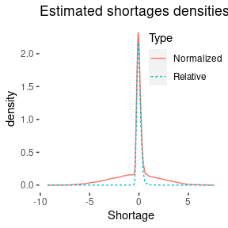

```r
if (requireNamespace("ggplot2", quietly = TRUE)) {
  pdt <- data.frame(
    Shortage = c(mdt$normalized_shortages, mdt$relative_shortages),
    Type = c(rep("Normalized", nrow(mdt)), rep("Relative", nrow(mdt))),
    xpos = c(rep(-1.0, nrow(mdt)), rep(1.0, nrow(mdt))),
    ypos = c(
      rep(0.8 * max(mdt$normalized_shortages), nrow(mdt)),
      rep(0.8 * max(mdt$relative_shortages), nrow(mdt))
    )
  )
  ggplot2::ggplot(pdt) +
    ggplot2::stat_density(ggplot2::aes(Shortage,
      linetype = Type,
      color = Type
    ), geom = "line") +
    ggplot2::ggtitle(paste0("Estimated shortages densities (", name(fit), ")")) +
    ggplot2::theme(
      panel.background = ggplot2::element_rect(fill = "transparent"),
      plot.background = ggplot2::element_rect(
        fill = "transparent",
        color = NA
      ),
      legend.background = ggplot2::element_rect(fill = "transparent"),
      legend.box.background = ggplot2::element_rect(
        fill = "transparent",
        color = NA
      ),
      legend.position = c(0.8, 0.8)
    )
} else {
    summary(mdt[, grep("shortage", colnames(mdt))])
}
```

### Fitted values and aggregation

The estimated demanded and supplied quantities can be calculated per observation.

```r
market <- cbind(
  demand = demanded_quantities(fit)[, 1],
  supply = supplied_quantities(fit)[, 1]
)
summary(market)
```

```
#>      demand          supply
#>  Min.   : 8.45   Min.   : 4.754
#>  1st Qu.:16.69   1st Qu.:16.746
#>  Median :18.57   Median :19.093
#>  Mean   :18.55   Mean   :19.115
#>  3rd Qu.:20.36   3rd Qu.:21.454
#>  Max.   :29.74   Max.   :30.763
```

The package also offers basic aggregation functionality.

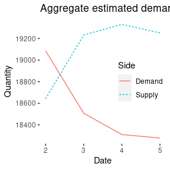

```r
aggregates <- aggregate_demand(fit) |>
  dplyr::left_join(aggregate_supply(fit), by = "date") |>
  dplyr::mutate(date = as.numeric(date)) |>
  dplyr::rename(demand = D_Q, supply = S_Q)
if (requireNamespace("ggplot2", quietly = TRUE)) {
  pdt <- data.frame(
    Date = c(aggregates$date, aggregates$date),
    Quantity = c(aggregates$demand, aggregates$supply),
    Side = c(rep("Demand", nrow(aggregates)), rep("Supply", nrow(aggregates)))
  )
  ggplot2::ggplot(pdt, ggplot2::aes(x = Date)) +
    ggplot2::geom_line(ggplot2::aes(y = Quantity, linetype = Side, color = Side)) +
    ggplot2::ggtitle(paste0(
      "Aggregate estimated demand and supply  (", name(fit), ")"
    )) +
    ggplot2::theme(
      panel.background = ggplot2::element_rect(fill = "transparent"),
      plot.background = ggplot2::element_rect(
        fill = "transparent", color = NA
      ),
      legend.background = ggplot2::element_rect(fill = "transparent"),
      legend.box.background = ggplot2::element_rect(
        fill = "transparent", color = NA
      ),
      legend.position = c(0.8, 0.5)
    )
} else {
    aggregates
}
```